# Lecture Notes

## Sep 24

### Testing models

We start by exploring the mtcars dataset and fitting a linear model to predict miles per gallon (mpg) based on the number of gears and horsepower:

```r
# Load mtcars dataset and explore gear distribution
data(mtcars)
table(mtcars$gear)
```

```
 3  4  5
15 12  5
```

```r
# Convert gear to factor (categorical variable)
mtcars$gear <- as.factor(mtcars$gear)

# Fit a linear model: mpg ~ gear + hp
mod <- lm(mpg ~ gear + hp, data = mtcars)
summary(mod)
```

```
Call:
lm(formula = mpg ~ gear + hp, data = mtcars)

Residuals:
    Min      1Q  Median      3Q     Max
-4.4937 -2.3586 -0.8277  2.2753  7.7287

Coefficients:
            Estimate Std. Error t value Pr(>|t|)
(Intercept) 27.88193    2.10908  13.220 1.47e-13 ***
gear4        2.63486    1.55164   1.698 0.100575
gear5        6.57476    1.64268   4.002 0.000417 ***
hp          -0.06685    0.01105  -6.052 1.59e-06 ***
---
Signif. codes:  0 '***' 0.001 '**' 0.01 '*' 0.05 '.' 0.1 ' ' 1

Residual standard error: 3.154 on 28 degrees of freedom
Multiple R-squared:  0.7527,    Adjusted R-squared:  0.7262
F-statistic: 28.41 on 3 and 28 DF,  p-value: 1.217e-08
```

```r
# Load multcomp for hypothesis testing
library(multcomp)
# Perform hypothesis tests on coefficients
summary(glht(mod, "(Intercept) = 0"))
```

```
     Simultaneous Tests for General Linear Hypotheses

Fit: lm(formula = mpg ~ gear + hp, data = mtcars)

Linear Hypotheses:
                 Estimate Std. Error t value Pr(>|t|)
(Intercept) == 0   27.882      2.109   13.22 1.47e-13 ***
---
Signif. codes:  0 '***' 0.001 '**' 0.01 '*' 0.05 '.' 0.1 ' ' 1
(Adjusted p values reported -- single-step method)
```

```r
summary(glht(mod, "(Intercept) + gear4 = 0"))
```

```
     Simultaneous Tests for General Linear Hypotheses

Fit: lm(formula = mpg ~ gear + hp, data = mtcars)

Linear Hypotheses:
                         Estimate Std. Error t value Pr(>|t|)
(Intercept) + gear4 == 0   30.517      1.344   22.71   <2e-16 ***
---
Signif. codes:  0 '***' 0.001 '**' 0.01 '*' 0.05 '.' 0.1 ' ' 1
(Adjusted p values reported -- single-step method)
```

```r
summary(glht(mod, "(Intercept) + gear5 = 0"))
```

```
     Simultaneous Tests for General Linear Hypotheses

Fit: lm(formula = mpg ~ gear + hp, data = mtcars)

Linear Hypotheses:
                         Estimate Std. Error t value Pr(>|t|)
(Intercept) + gear5 == 0    34.46       2.58   13.35 1.15e-13 ***
---
Signif. codes:  0 '***' 0.001 '**' 0.01 '*' 0.05 '.' 0.1 ' ' 1
(Adjusted p values reported -- single-step method)
```

```r
summary(glht(mod, "gear4 = 0"))
```

```
     Simultaneous Tests for General Linear Hypotheses

Fit: lm(formula = mpg ~ gear + hp, data = mtcars)

Linear Hypotheses:
           Estimate Std. Error t value Pr(>|t|)
gear4 == 0    2.635      1.552   1.698    0.101
(Adjusted p values reported -- single-step method)
```

```r
summary(glht(mod, "gear5 = 0"))
```

```
     Simultaneous Tests for General Linear Hypotheses

Fit: lm(formula = mpg ~ gear + hp, data = mtcars)

Linear Hypotheses:
           Estimate Std. Error t value Pr(>|t|)
gear5 == 0    6.575      1.643   4.002 0.000417 ***
---
Signif. codes:  0 '***' 0.001 '**' 0.01 '*' 0.05 '.' 0.1 ' ' 1
(Adjusted p values reported -- single-step method)
```

```r
summary(glht(mod, "gear4 - gear5 = 0"))
```

```
     Simultaneous Tests for General Linear Hypotheses

Fit: lm(formula = mpg ~ gear + hp, data = mtcars)

Linear Hypotheses:
                   Estimate Std. Error t value Pr(>|t|)
gear4 - gear5 == 0   -3.940      2.047  -1.924   0.0645 .
---
Signif. codes:  0 '***' 0.001 '**' 0.01 '*' 0.05 '.' 0.1 ' ' 1
(Adjusted p values reported -- single-step method)
```

```r
# Complex linear combination hypothesis
summary(glht(mod, "hp - 2*gear5 + (1/4)*gear4 = 17"))
```

```
     Simultaneous Tests for General Linear Hypotheses

Fit: lm(formula = mpg ~ gear + hp, data = mtcars)

Linear Hypotheses:
                                     Estimate Std. Error t value Pr(>|t|)
hp - 2 * gear5 + (1/4) * gear4 == 17  -12.558      3.241  -9.121 7.05e-10 ***
---
Signif. codes:  0 '***' 0.001 '**' 0.01 '*' 0.05 '.' 0.1 ' ' 1
(Adjusted p values reported -- single-step method)
```

Next, we explore the relationship between the number of years married and the heights of husbands and wives from a separate dataset:

```r
# Load husbands_wives dataset and fit a linear model
hw <- read.csv("data/husbands_wives.csv")
mod2 <- lm(years_married ~ ht_husband + ht_wife, data = hw)
summary(mod2)
```

```
Call:
lm(formula = years_married ~ ht_husband + ht_wife, data = hw)

Residuals:
    Min      1Q  Median      3Q     Max
-22.192  -8.710  -0.214   8.515  22.091

Coefficients:
            Estimate Std. Error t value Pr(>|t|)
(Intercept) 96.19689   23.37953   4.115 5.75e-05 ***
ht_husband  -0.02554    0.01189  -2.149   0.0329 *
ht_wife     -0.02162    0.01305  -1.657   0.0992 .
---
Signif. codes:  0 '***' 0.001 '**' 0.01 '*' 0.05 '.' 0.1 ' ' 1

Residual standard error: 10.63 on 192 degrees of freedom
  (4 observations deleted due to missingness)
Multiple R-squared:  0.05655,   Adjusted R-squared:  0.04672
F-statistic: 5.754 on 2 and 192 DF,  p-value: 0.003742
```

```r
# Test equality of height coefficients
summary(glht(mod2, "ht_husband - ht_wife = 0"))
```

```
     Simultaneous Tests for General Linear Hypotheses

Fit: lm(formula = years_married ~ ht_husband + ht_wife, data = hw)

Linear Hypotheses:
                           Estimate Std. Error t value Pr(>|t|)
ht_husband - ht_wife == 0 -0.003919   0.020623   -0.19    0.849
(Adjusted p values reported -- single-step method)
```

We now use estimated marginal means (EMMs) to explore the effect of gears on mpg and compare means across gear levels:

```r
# Load emmeans for estimated marginal means (lsmeans)
library(emmeans)
emmeans(mod, ~ gear)
```

```
 gear emmean    SE df lower.CL upper.CL
 3      18.1 0.877 28     16.3     19.9
 4      20.7 1.110 28     18.4     23.0
 5      24.7 1.510 28     21.6     27.7

Confidence level used: 0.95
```

```r
# Additional hypothesis tests
summary(glht(mod, "(Intercept) + 146.6875*hp = 0"))
```

```
     Simultaneous Tests for General Linear Hypotheses

Fit: lm(formula = mpg ~ gear + hp, data = mtcars)

Linear Hypotheses:
                                 Estimate Std. Error t value Pr(>|t|)
(Intercept) + 146.6875 * hp == 0  18.0752     0.8768   20.61   <2e-16 ***
---
Signif. codes:  0 '***' 0.001 '**' 0.01 '*' 0.05 '.' 0.1 ' ' 1
(Adjusted p values reported -- single-step method)
```

```r
summary(glht(mod, "(Intercept) + gear4 + 146.6875*hp = 0"))
```

```
     Simultaneous Tests for General Linear Hypotheses

Fit: lm(formula = mpg ~ gear + hp, data = mtcars)

Linear Hypotheses:
                                         Estimate Std. Error t value Pr(>|t|)
(Intercept) + gear4 + 146.6875 * hp == 0   20.710      1.108   18.69   <2e-16

(Intercept) + gear4 + 146.6875 * hp == 0 ***
---
Signif. codes:  0 '***' 0.001 '**' 0.01 '*' 0.05 '.' 0.1 ' ' 1
(Adjusted p values reported -- single-step method)
```

```r
summary(glht(mod, "(Intercept) + gear5 + 146.6875*hp = 0"))
```

```
     Simultaneous Tests for General Linear Hypotheses

Fit: lm(formula = mpg ~ gear + hp, data = mtcars)

Linear Hypotheses:
                                         Estimate Std. Error t value Pr(>|t|)
(Intercept) + gear5 + 146.6875 * hp == 0    24.65       1.51   16.32 7.77e-16

(Intercept) + gear5 + 146.6875 * hp == 0 ***
---
Signif. codes:  0 '***' 0.001 '**' 0.01 '*' 0.05 '.' 0.1 ' ' 1
(Adjusted p values reported -- single-step method)
```

```r
# Test and compare marginal means by gear level
test(emmeans(mod, ~ gear))
```

```
 gear emmean    SE df t.ratio p.value
 3      18.1 0.877 28  20.614  <.0001
 4      20.7 1.110 28  18.690  <.0001
 5      24.7 1.510 28  16.321  <.0001
```

```r
pairs(emmeans(mod, ~ gear), adjust = "none")
```

```
 contrast      estimate   SE df t.ratio p.value
 gear3 - gear4    -2.63 1.55 28  -1.698  0.1006
 gear3 - gear5    -6.57 1.64 28  -4.002  0.0004
 gear4 - gear5    -3.94 2.05 28  -1.924  0.0645
```

We can also visualize how the relationship between predictors changes using interaction terms:

```r
# Load marginaleffects and ggeffects
library(marginaleffects)
library(ggeffects)

# Fit a model with an interaction term: mpg ~ gear * hp
mod3 <- lm(mpg ~ gear * hp, data = mtcars)
summary(mod3)
```

```
Call:
lm(formula = mpg ~ gear * hp, data = mtcars)

Residuals:
   Min     1Q Median     3Q    Max
-5.061 -1.505  0.140  1.491  4.977

Coefficients:
             Estimate Std. Error t value Pr(>|t|)
(Intercept) 25.307903   2.650811   9.547 5.51e-10 ***
gear4       15.262616   3.862728   3.951 0.000531 ***
gear5        7.469550   3.805534   1.963 0.060451 .
hp          -0.052240   0.014560  -3.588 0.001356 **
gear4:hp    -0.126946   0.033574  -3.781 0.000825 ***
gear5:hp    -0.006029   0.019276  -0.313 0.756952
---
Signif. codes:  0 '***' 0.001 '**' 0.01 '*' 0.05 '.' 0.1 ' ' 1

Residual standard error: 2.598 on 26 degrees of freedom
Multiple R-squared:  0.8441,    Adjusted R-squared:  0.8142
F-statistic: 28.16 on 5 and 26 DF,  p-value: 1.024e-09
```

```r
# Hypothesis tests for interaction effects
summary(glht(mod3, "hp = 0"))
```

```
     Simultaneous Tests for General Linear Hypotheses

Fit: lm(formula = mpg ~ gear * hp, data = mtcars)

Linear Hypotheses:
        Estimate Std. Error t value Pr(>|t|)
hp == 0 -0.05224    0.01456  -3.588  0.00136 **
---
Signif. codes:  0 '***' 0.001 '**' 0.01 '*' 0.05 '.' 0.1 ' ' 1
(Adjusted p values reported -- single-step method)
```

```r
summary(glht(mod3, "hp + gear4:hp = 0"))
```

```
     Simultaneous Tests for General Linear Hypotheses

Fit: lm(formula = mpg ~ gear * hp, data = mtcars)

Linear Hypotheses:
                   Estimate Std. Error t value Pr(>|t|)
hp + gear4:hp == 0 -0.17919    0.03025  -5.923    3e-06 ***
---
Signif. codes:  0 '***' 0.001 '**' 0.01 '*' 0.05 '.' 0.1 ' ' 1
(Adjusted p values reported -- single-step method)
```

```r
summary(glht(mod3, "hp + gear5:hp = 0"))
```

```
     Simultaneous Tests for General Linear Hypotheses

Fit: lm(formula = mpg ~ gear * hp, data = mtcars)

Linear Hypotheses:
                   Estimate Std. Error t value Pr(>|t|)
hp + gear5:hp == 0 -0.05827    0.01263  -4.613 9.34e-05 ***
---
Signif. codes:  0 '***' 0.001 '**' 0.01 '*' 0.05 '.' 0.1 ' ' 1
(Adjusted p values reported -- single-step method)
```

```r
# Test individual and comparative interaction terms
summary(glht(mod3, "gear4:hp = 0"))
```

```
     Simultaneous Tests for General Linear Hypotheses

Fit: lm(formula = mpg ~ gear * hp, data = mtcars)

Linear Hypotheses:
              Estimate Std. Error t value Pr(>|t|)
gear4:hp == 0 -0.12695    0.03357  -3.781 0.000825 ***
---
Signif. codes:  0 '***' 0.001 '**' 0.01 '*' 0.05 '.' 0.1 ' ' 1
(Adjusted p values reported -- single-step method)
```

```r
summary(glht(mod3, "gear5:hp = 0"))
```

```
     Simultaneous Tests for General Linear Hypotheses

Fit: lm(formula = mpg ~ gear * hp, data = mtcars)

Linear Hypotheses:
               Estimate Std. Error t value Pr(>|t|)
gear5:hp == 0 -0.006029   0.019276  -0.313    0.757
(Adjusted p values reported -- single-step method)
```

```r
summary(glht(mod3, "gear4:hp - gear5:hp = 0"))
```

```
     Simultaneous Tests for General Linear Hypotheses

Fit: lm(formula = mpg ~ gear * hp, data = mtcars)

Linear Hypotheses:
                         Estimate Std. Error t value Pr(>|t|)
gear4:hp - gear5:hp == 0 -0.12092    0.03278  -3.688  0.00105 **
---
Signif. codes:  0 '***' 0.001 '**' 0.01 '*' 0.05 '.' 0.1 ' ' 1
(Adjusted p values reported -- single-step method)
```

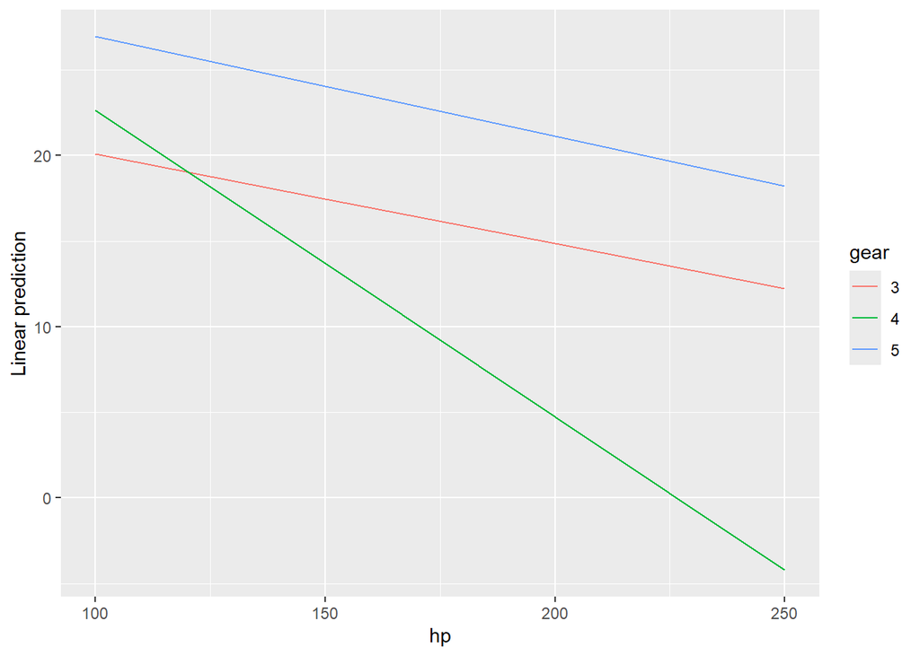

```r
# Plot interaction effects using emmip and interact_plot
emmip(mod3, gear ~ hp, at = list(hp = c(100, 150, 200, 250)))
```

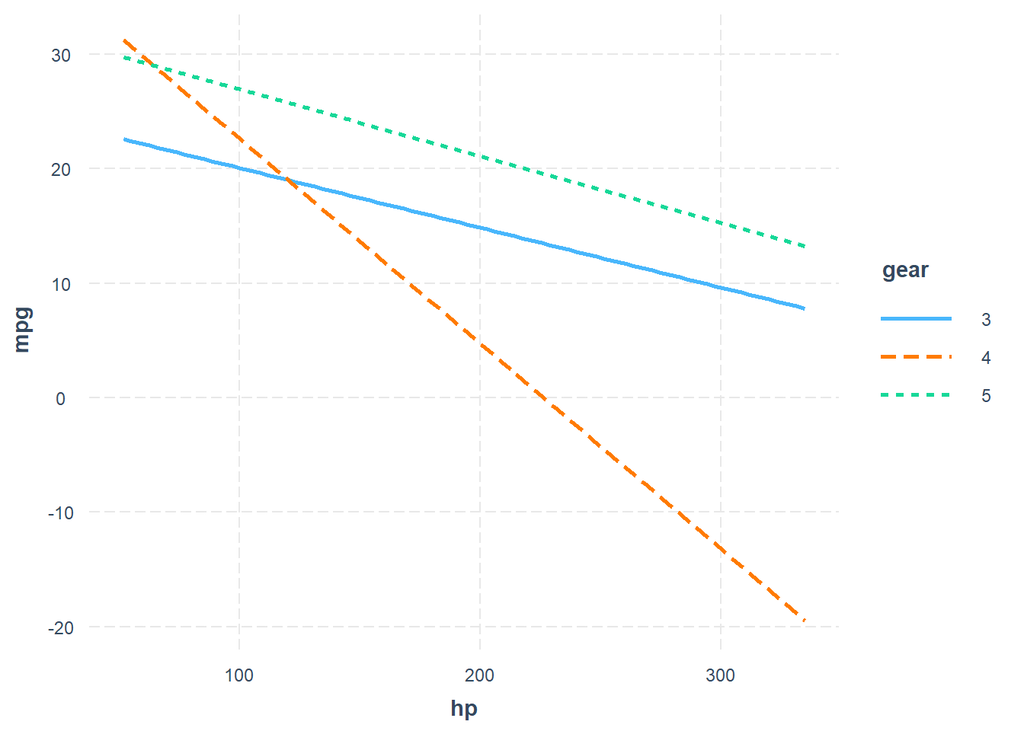

```r
library(interactions)
interact_plot(mod3, pred = "hp", modx = "gear")
```

We can also fit a generalized linear model (GLM) for binary outcomes, such as automatic vs. manual transmission (am), and explore interaction terms:

```r
# Fit a generalized linear model: am ~ gear * hp (binary outcome)
mod4 <- glm(am ~ gear * hp, data = mtcars, family = binomial)
summary(mod4)
```

```
Call:
glm(formula = am ~ gear * hp, family = binomial, data = mtcars)

Coefficients:
              Estimate Std. Error z value Pr(>|z|)
(Intercept) -2.057e+01  1.809e+04  -0.001    0.999
gear4        2.401e+01  1.809e+04   0.001    0.999
gear5        4.113e+01  2.597e+04   0.002    0.999
hp           1.183e-09  9.936e+01   0.000    1.000
gear4:hp    -2.975e-02  9.936e+01   0.000    1.000
gear5:hp    -1.183e-09  1.315e+02   0.000    1.000

(Dispersion parameter for binomial family taken to be 1)

    Null deviance: 43.23  on 31  degrees of freedom
Residual deviance: 13.99  on 26  degrees of freedom
AIC: 25.99

Number of Fisher Scoring iterations: 19
```

```r
# Predictions and marginal means for glm
head(predict(mod4))
```

```
        Mazda RX4     Mazda RX4 Wag        Datsun 710    Hornet 4 Drive
        0.1752313         0.1752313         0.6809211       -20.5660686
Hornet Sportabout           Valiant
      -20.5660685       -20.5660686
```

```r
emmeans(mod4, ~ gear)
```

```
NOTE: Results may be misleading due to involvement in interactions
```

```
 gear  emmean      SE  df asymp.LCL asymp.UCL
 3    -20.566 5430.00 Inf -10669.24  10628.10
 4     -0.916    1.56 Inf     -3.97      2.14
 5     20.566 8980.00 Inf -17581.36  17622.49

Results are given on the logit (not the response) scale.
Confidence level used: 0.95
```

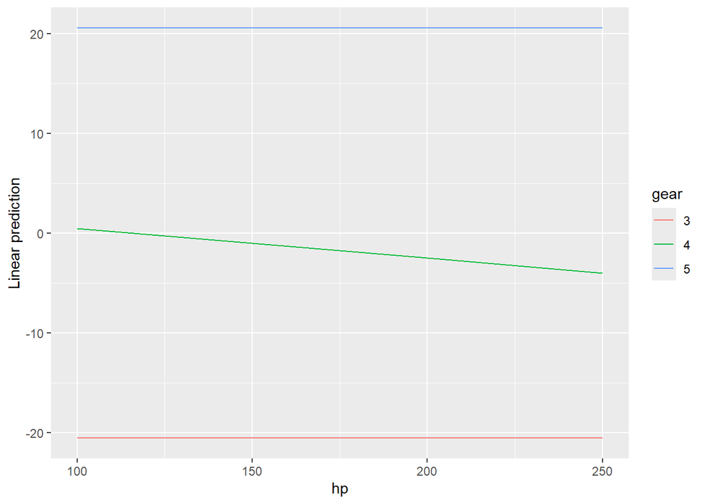

```r
# Plot interaction effects for glm
emmip(mod4, gear ~ hp, at = list(hp = c(100, 150, 200, 250)))
```

Lastly, we explore mixed effects models, which allow us to model data with hierarchical structure or random effects:

```r
# Load libraries for mixed effects models
library(lme4)
library(lmerTest)
# Explore InstEval dataset
head(InstEval)
```

```
  s    d studage lectage service dept y
1 1 1002       2       2       0    2 5
2 1 1050       2       1       1    6 2
3 1 1582       2       2       0    2 5
4 1 2050       2       2       1    3 3
5 2  115       2       1       0    5 2
6 2  756       2       1       0    5 4
```

```r
# Fit a mixed effects model with random intercept
mod5 <- lmer(y ~ service + (1 | s), data = InstEval)
summary(mod5)
```

```
Linear mixed model fit by REML. t-tests use Satterthwaite's method [
lmerModLmerTest]
Formula: y ~ service + (1 | s)
   Data: InstEval

REML criterion at convergence: 248648.9

Scaled residuals:
     Min       1Q   Median       3Q      Max
-2.30732 -0.81704 -0.00874  0.77436  2.12868

Random effects:
 Groups   Name        Variance Std.Dev.
 s        (Intercept) 0.09962  0.3156
 Residual             1.67264  1.2933
Number of obs: 73421, groups:  s, 2972

Fixed effects:
              Estimate Std. Error         df t value Pr(>|t|)
(Intercept)  3.264e+00  8.971e-03  4.606e+03  363.83   <2e-16 ***
service1    -1.253e-01  9.967e-03  7.317e+04  -12.58   <2e-16 ***
---
Signif. codes:  0 '***' 0.001 '**' 0.01 '*' 0.05 '.' 0.1 ' ' 1

Correlation of Fixed Effects:
         (Intr)
service1 -0.485
```

```r
# Predictions from the mixed effects model
head(predict(mod5))
```

```
       1        2        3        4        5        6
3.369527 3.244182 3.369527 3.244182 3.235863 3.235863
```

### SQLite

This section demonstrates how to interact with SQLite databases in R using the DBI and RSQLite libraries. We connect to the Lahman baseball database and run queries to retrieve data.

```r
# Load necessary libraries for database interaction
library(DBI)
library(RSQLite)

# Connect to the Lahman database
lahman <- dbConnect(SQLite(), "data/lahman_1871-2022.sqlite")

# Check the connection object
lahman
```

```
<SQLiteConnection>
  Path: D:\RStudio\stat506\data\lahman_1871-2022.sqlite
  Extensions: TRUE
```

```r
# List the available tables in the database
dbListTables(lahman)
```

```
 [1] "AllstarFull"         "Appearances"         "AwardsManagers"
 [4] "AwardsPlayers"       "AwardsShareManagers" "AwardsSharePlayers"
 [7] "Batting"             "BattingPost"         "CollegePlaying"
[10] "Fielding"            "FieldingOF"          "FieldingOFsplit"
[13] "FieldingPost"        "HallOfFame"          "HomeGames"
[16] "Managers"            "ManagersHalf"        "Parks"
[19] "People"              "Pitching"            "PitchingPost"
[22] "Salaries"            "Schools"             "SeriesPost"
[25] "Teams"               "TeamsFranchises"     "TeamsHalf"
```

```r
# List the fields (columns) in the 'People' table
dbListFields(lahman, "People")
```

```
 [1] "ID"           "playerID"     "birthYear"    "birthMonth"   "birthDay"
 [6] "birthCity"    "birthCountry" "birthState"   "deathYear"    "deathMonth"
[11] "deathDay"     "deathCountry" "deathState"   "deathCity"    "nameFirst"
[16] "nameLast"     "nameGiven"    "weight"       "height"       "bats"
[21] "throws"       "debut"        "bbrefID"      "finalGame"    "retroID"
```

```r
# Retrieve and display some data from the 'People' table
dbGetQuery(lahman, "SELECT playerID FROM people LIMIT 6")
```

```
   playerID
1 aardsda01
2 aaronha01
3 aaronto01
4  aasedo01
5  abadan01
6  abadfe01
```

```r
head(dbGetQuery(lahman, "SELECT playerID FROM people"))
```

```
   playerID
1 aardsda01
2 aaronha01
3 aaronto01
4  aasedo01
5  abadan01
6  abadfe01
```

## Sep 26

### More on SQL

Continuing from last time, this section explores database querying and SQL operations using the Lahman baseball database through R’s DBI and RSQLite libraries.

```r
# Load libraries for SQLite database interaction
library(DBI)
library(RSQLite)

# Connect to the Lahman database
lahman <- dbConnect(SQLite(), "data/lahman_1871-2022.sqlite")

# Query the 'batting' table and display first 5 rows
dbGetQuery(lahman, "
SELECT *
  FROM batting
 LIMIT 5
")
```

```
   playerID yearID stint teamID lgID  G G_batting AB R H 2B 3B HR RBI SB CS BB
1 aardsda01   2004     1    SFN   NL 11        NA  0 0 0  0  0  0   0  0  0  0
2 aardsda01   2006     1    CHN   NL 45        NA  2 0 0  0  0  0   0  0  0  0
3 aardsda01   2007     1    CHA   AL 25        NA  0 0 0  0  0  0   0  0  0  0
4 aardsda01   2008     1    BOS   AL 47        NA  1 0 0  0  0  0   0  0  0  0
5 aardsda01   2009     1    SEA   AL 73        NA  0 0 0  0  0  0   0  0  0  0
  SO IBB HBP SH SF GIDP G_old
1  0   0   0  0  0    0    NA
2  0   0   0  1  0    0    NA
3  0   0   0  0  0    0    NA
4  1   0   0  0  0    0    NA
5  0   0   0  0  0    0    NA
```

```r
# Define a query function to simplify SQL queries
gg <- function(query) {
  dbGetQuery(lahman, query)
}

# Example usage of the query function
gg("
SELECT *
  FROM batting
 LIMIT 5
")
```

```
   playerID yearID stint teamID lgID  G G_batting AB R H 2B 3B HR RBI SB CS BB
1 aardsda01   2004     1    SFN   NL 11        NA  0 0 0  0  0  0   0  0  0  0
2 aardsda01   2006     1    CHN   NL 45        NA  2 0 0  0  0  0   0  0  0  0
3 aardsda01   2007     1    CHA   AL 25        NA  0 0 0  0  0  0   0  0  0  0
4 aardsda01   2008     1    BOS   AL 47        NA  1 0 0  0  0  0   0  0  0  0
5 aardsda01   2009     1    SEA   AL 73        NA  0 0 0  0  0  0   0  0  0  0
  SO IBB HBP SH SF GIDP G_old
1  0   0   0  0  0    0    NA
2  0   0   0  1  0    0    NA
3  0   0   0  0  0    0    NA
4  1   0   0  0  0    0    NA
5  0   0   0  0  0    0    NA
```

We can inspect the structure of the database by listing tables and fields:

```r
# List tables in the database
dbListTables(lahman)
```

```
 [1] "AllstarFull"         "Appearances"         "AwardsManagers"
 [4] "AwardsPlayers"       "AwardsShareManagers" "AwardsSharePlayers"
 [7] "Batting"             "BattingPost"         "CollegePlaying"
[10] "Fielding"            "FieldingOF"          "FieldingOFsplit"
[13] "FieldingPost"        "HallOfFame"          "HomeGames"
[16] "Managers"            "ManagersHalf"        "Parks"
[19] "People"              "Pitching"            "PitchingPost"
[22] "Salaries"            "Schools"             "SeriesPost"
[25] "Teams"               "TeamsFranchises"     "TeamsHalf"
```

```r
# Get the number of fields in the 'HallOfFame' table
length(dbListFields(lahman, "HallOfFame"))
```

```
[1] 9
```

```r
# Count the number of player IDs in the 'HallOfFame' table
gg("
SELECT COUNT(playerid)
  FROM halloffame
")
```

```
  COUNT(playerid)
1            4323
```

```r
# Query player IDs by specific year ranges
gg("
SELECT COUNT(playerid)
  FROM halloffame
 WHERE (yearid > 2004 AND yearid < 2010) OR yearid > 2015
")
```

```
  COUNT(playerid)
1             394
```

```r
# Retrieve player IDs and years from 'HallOfFame' table
table <- gg("
SELECT playerid, yearID
  FROM halloffame
")

# Filter the table to specific year ranges
nrow(table[(table$yearid > 2004 & table$yearid < 2010) | table$yearid > 2015, ])
```

```
[1] 394
```

We can also explore string filtering, grouping, and aggregations with SQL queries:

```r
# List fields from the 'people' table
dbListFields(lahman, "people")
```

```
 [1] "ID"           "playerID"     "birthYear"    "birthMonth"   "birthDay"
 [6] "birthCity"    "birthCountry" "birthState"   "deathYear"    "deathMonth"
[11] "deathDay"     "deathCountry" "deathState"   "deathCity"    "nameFirst"
[16] "nameLast"     "nameGiven"    "weight"       "height"       "bats"
[21] "throws"       "debut"        "bbrefID"      "finalGame"    "retroID"
```

```r
# Count players with last name 'Griffey'
gg("
SELECT COUNT(nameFirst)
  FROM people
 WHERE nameLast = 'Griffey'
 LIMIT 5
")
```

```
  COUNT(nameFirst)
1                2
```

```r
# Count players with last names 'Griffey' or 'Aaron'
gg("
SELECT COUNT(nameFirst)
  FROM people
 WHERE nameLast IN ('Griffey', 'Aaron')
")
```

```
  COUNT(nameFirst)
1                4
```

```r
# Retrieve last names matching a pattern
gg("
SELECT nameLast
  FROM people
 WHERE nameLast LIKE '%iff%'
 LIMIT 5
")
```

```
  nameLast
1  Chiffer
2  Cunniff
3  Gifford
4  Griffin
5  Griffin
```

We use sorting, grouping, and aggregation functions to summarize statistics:

```r
# List fields in the 'Batting' table
dbListFields(lahman, "Batting")
```

```
 [1] "playerID"  "yearID"    "stint"     "teamID"    "lgID"      "G"
 [7] "G_batting" "AB"        "R"         "H"         "2B"        "3B"
[13] "HR"        "RBI"       "SB"        "CS"        "BB"        "SO"
[19] "IBB"       "HBP"       "SH"        "SF"        "GIDP"      "G_old"
```

```r
# Get players with more than 10 home runs, sorted by HR in descending order
gg("
SELECT playerid, hr
  FROM batting
 WHERE hr > 10
 ORDER BY -HR
 LIMIT 10
")
```

```
    playerID HR
1  bondsba01 73
2  mcgwima01 70
3   sosasa01 66
4  mcgwima01 65
5   sosasa01 64
6   sosasa01 63
7  judgeaa01 62
8  marisro01 61
9   ruthba01 60
10  ruthba01 59
```

```r
# Sum of home runs per player after 2010
gg("
SELECT playerid AS name, SUM(hr) AS sum_hr
  FROM Batting
 WHERE yearid > 2010
 GROUP BY playerid
 ORDER BY -sum_hr
 LIMIT 5
")
```

```
       name sum_hr
1  cruzne02    382
2 stantmi03    356
3 troutmi01    350
4 encared01    324
5 goldspa01    315
```

```r
# Players with total HRs > 340 after 2010
gg("
SELECT playerid AS name, SUM(hr) AS sum_hr
  FROM Batting
 WHERE yearid > 2010
 GROUP BY playerid
 HAVING sum_hr > 340
 ORDER BY -sum_hr
 LIMIT 5
")
```

```
       name sum_hr
1  cruzne02    382
2 stantmi03    356
3 troutmi01    350
```

We explore joins to combine data across tables:

```r
# Inner join between 'batting' and 'people' tables
gg("
SELECT batting.playerid AS pid, batting.hr, people.namelast
  FROM batting
 INNER JOIN people
            ON batting.playerid = people.playerid
 LIMIT 5
")
```

```
        pid HR nameLast
1 aardsda01  0  Aardsma
2 aardsda01  0  Aardsma
3 aardsda01  0  Aardsma
4 aardsda01  0  Aardsma
5 aardsda01  0  Aardsma
```

```r
# Join with aliasing for tables
gg("
SELECT b.playerid AS pid, b.hr, p.namelast
  FROM batting AS b
 INNER JOIN people AS p
            ON b.playerid = p.playerid
 LIMIT 5
")
```

```
        pid HR nameLast
1 aardsda01  0  Aardsma
2 aardsda01  0  Aardsma
3 aardsda01  0  Aardsma
4 aardsda01  0  Aardsma
5 aardsda01  0  Aardsma
```

We also use nested queries for more complex operations:

```r
# Sum HRs per player with inner join and filter by year
gg("
SELECT p.playerid, SUM(b.hr) AS sum_hr
  FROM Batting AS b
 INNER JOIN
       (SELECT playerid, namefirst, namelast
          FROM people) AS p
          ON b.playerid = p.playerid
 WHERE yearid > 2010
 GROUP BY p.playerid
 ORDER BY -sum_hr
 LIMIT 5
")
```

```
   playerid sum_hr
1  cruzne02    382
2 stantmi03    356
3 troutmi01    350
4 encared01    324
5 goldspa01    315
```

Lastly, we explore college and award data through joins and aggregations:

```r
# Find last year a player appeared in college
gg("
SELECT playerid, schoolid, MAX(yearID) AS lastyear
  FROM collegeplaying
 GROUP BY playerid
 LIMIT 10
")
```

```
    playerID   schoolID lastyear
1  aardsda01       rice     2003
2   abadan01    gamiddl     1993
3  abbeybe01    vermont     1892
4  abbotje01   kentucky     1994
5  abbotji01   michigan     1988
6  abbotky01  longbeach     1989
7  abercre01  flgateway     2000
8  abernte01       elon     1941
9  ablesha01 swesterntx     1904
10 accarje01 illinoisst     2003
```

```r
# Retrieve award winners with maximum year of college attendance
gg("
SELECT a.playerid, c.schoolid
  FROM collegeplaying AS c
  LEFT JOIN (
       SELECT playerid, awardid
         FROM awardsplayers
        WHERE awardid LIKE 'Rookie%'
       ) AS a ON a.playerid = c.playerid
 GROUP BY a.playerid
 HAVING c.yearid = MAX(c.yearid)
 LIMIT 10
")
```

```
    playerid   schoolID
1       <NA>   txchrist
2   ageeto01  grambling
3  allisbo01     kansas
4  bagweje01   hartford
5  bahnsst01   nebraska
6  bailean01     wagner
7    bayja01    gonzaga
8  blefacu01     wagner
9  braunry02    miamifl
10 bumbral01 virginiast
```

```r
# Count of players by school who won Rookie awards
gg("
SELECT schoolID, count(schoolID) AS count
  FROM (SELECT a.playerid, c.schoolid
          FROM collegeplaying AS c
          LEFT JOIN (
               SELECT playerid, awardid
                 FROM awardsplayers
                WHERE awardid LIKE 'Rookie%'
                   ) AS a ON a.playerid = c.playerid
         GROUP BY a.playerid
        HAVING c.yearid = MAX(c.yearid))
 GROUP BY schoolID
 ORDER BY -count
 LIMIT 5
")
```

```
   schoolid count
1 arizonast     4
2  michigan     3
3      ucla     3
4       usc     3
5 floridaam     2
```

### String Manipulation in R

```r
# Checking the type of strings
typeof("abc")
```

```
[1] "character"
```

```r
typeof('abc')
```

```
[1] "character"
```

```r
# Using quotes within strings
'this is a "scare quote"'
```

```
[1] "this is a \"scare quote\""
```

```r
"this is a 'scare quote'"
```

```
[1] "this is a 'scare quote'"
```

```r
# Printing with newlines and escape characters
print("abc\ndef")
```

```
[1] "abc\ndef"
```

```r
cat("abc\ndef")
```

```
abc
def
```

```r
# Using backslashes
print("I want a backslash: \\")
```

```
[1] "I want a backslash: \\"
```

```r
cat("I want a backslash: \\")
```

```
I want a backslash: \
```

### String Operations and Pattern Matching

```r
# Simple string operations
s <- "abcdefghi"
substr(s, 3, 5) <- "XYZ"
s
```

```
[1] "abXYZfghi"
```

```r
# grep and grepl for pattern matching
grep("abc", "abcdefgfh")
```

```
[1] 1
```

```r
grepl("abc", c("abcdef", "defghi"))
```

```
[1]  TRUE FALSE
```

```r
# Read and manipulate a list of powers from a URL
powers <- tolower(readLines("https://raw.githubusercontent.com/nolshru/SuperpowerRandSelector/main/PlaintextSuperpowerList.txt"))
powers[grep("arts", powers)]
```

```
[1] "mixed martial arts intuition"   "secret arts"
[3] "animalistic martial arts"       "mystical martial arts"
[5] "ninpo arts"                     "fictional martial arts mastery"
[7] "martial arts mastery"           "dark arts"
[9] "white arts"
```

### Regular Expressions in R

```r
# Find words with specific patterns
head(powers[grepl("^q", powers)])
```

```
[1] "quantum string manipulation" "qinggong mastery"
[3] "qigong mastery"
```

```r
head(powers[grepl("q[ui]e", powers)])
```

```
[1] "etiquette intuition" "equestrian mastery"
```

```r
head(powers[grepl("[aeiou]{2,4}", powers)])
```

```
[1] "enhanced speed"             "biological manipulation"
[3] "blood manipulation"         "body function manipulation"
[5] "bone manipulation"          "dna manipulation"
```

```r
# Use quantifiers and wildcards
head(powers[grepl("p[e]+d", powers)])
```

```
[1] "enhanced speed"         "pedagogy intuition"     "encyclopedic knowledge"
```

```r
head(powers[grepl("p.*d", powers)])
```

```
[1] "enhanced speed"              "supernatural blood"
[3] "intuitive aptitude"          "relationship identification"
[5] "pedagogy intuition"          "lip reading intuition"
```

```r
# Match specific patterns
head(grepl("a\\.c", c("abc", "a.c")))
```

```
[1] FALSE  TRUE
```

## Oct 01

### SQL Queries and String Manipulation in R

This lecture demonstrates SQL querying using the Sakila database and string operations in R.

```r
# Load required libraries
library(DBI)
library(RSQLite)

# Connect to the Sakila database
sakila <- dbConnect(SQLite(), "data/sakila_master.db")

# List all tables in the database
dbListTables(sakila)
```

```
 [1] "actor"                  "address"                "category"
 [4] "city"                   "country"                "customer"
 [7] "customer_list"          "film"                   "film_actor"
[10] "film_category"          "film_list"              "film_text"
[13] "inventory"              "language"               "payment"
[16] "rental"                 "sales_by_film_category" "sales_by_store"
[19] "staff"                  "staff_list"             "store"
```

```r
# Define a query function
gg <- function(query) {
  dbGetQuery(sakila, query)
}

# Query to join rental and inventory tables
gg("
SELECT i.film_id
  FROM rental AS r
  LEFT JOIN inventory AS i ON i.inventory_id = r.inventory_id
 LIMIT 50
")
```

```
   film_id
1        1
2        1
3        1
4        1
5        1
6        1
7        1
8        1
9        1
10       1
11       1
12       1
13       1
14       1
```

[output cut: 36 more lines]

```r
# Query with nested joins and ordering
gg("
SELECT fa.actor_id, ri.film_id, ri.customer_id
  FROM film_actor AS fa
 RIGHT JOIN (
      SELECT i.film_id, r.customer_id
        FROM rental AS r
        LEFT JOIN inventory AS i ON i.inventory_id = r.inventory_id
      ) AS ri ON ri.film_id = fa.film_id
 ORDER BY ri.film_id, ri.customer_id, fa.actor_id
 LIMIT 50
")
```

```
   actor_id film_id customer_id
1         1       1           8
2        10       1           8
3        20       1           8
4        30       1           8
5        40       1           8
6        53       1           8
7       108       1           8
8       162       1           8
9       188       1           8
10      198       1           8
11        1       1          34
12       10       1          34
13       20       1          34
14       30       1          34
```

[output cut: 36 more lines]

```r
# Query to join actor and rental data
gg("
SELECT a.first_name, a.last_name, fari.film_id, fari.customer_id
  FROM actor AS a
 RIGHT JOIN (
      SELECT fa.actor_id, ri.film_id, ri.customer_id
        FROM film_actor AS fa
       RIGHT JOIN (
            SELECT i.film_id, r.customer_id
              FROM rental AS r
              LEFT JOIN inventory AS i ON i.inventory_id = r.inventory_id
            ) AS ri ON ri.film_id = fa.film_id
      ) AS fari ON fari.actor_id = a.actor_id
 LIMIT 5
")
```

```
  first_name last_name film_id customer_id
1   PENELOPE   GUINESS       1         587
2   PENELOPE   GUINESS       1         411
3   PENELOPE   GUINESS       1         345
4   PENELOPE   GUINESS       1         170
5   PENELOPE   GUINESS       1         597
```

```r
# Query to count actor appearances
gg("
SELECT COUNT(a.actor_id) AS count, a.first_name, a.last_name
  FROM actor AS a
 RIGHT JOIN (
      SELECT fa.actor_id, ri.film_id, ri.customer_id
        FROM film_actor AS fa
       RIGHT JOIN (
            SELECT i.film_id, r.customer_id
              FROM rental AS r
              LEFT JOIN inventory AS i ON i.inventory_id = r.inventory_id
            ) AS ri ON ri.film_id = fa.film_id
      ) AS fari ON fari.actor_id = a.actor_id
 GROUP BY a.actor_id
 ORDER BY -count
 LIMIT 5
")
```

```
  count first_name   last_name
1   753       GINA   DEGENERES
2   678    MATTHEW      CARREY
3   674       MARY      KEITEL
4   654     ANGELA WITHERSPOON
5   640     WALTER        TORN
```

### String Operations in R

```r
# Basic string operations
"abc"
```

```
[1] "abc"
```

```r
'abc'
```

```
[1] "abc"
```

```r
typeof("abc")
```

```
[1] "character"
```

```r
typeof('abc')
```

```
[1] "character"
```

```r
# Using quotes within strings
'this is a "scare quote"'
```

```
[1] "this is a \"scare quote\""
```

```r
"this is a 'scare quote'"
```

```
[1] "this is a 'scare quote'"
```

```r
# Printing with escape characters
print("abc\ndef")
```

```
[1] "abc\ndef"
```

```r
cat("abc\ndef")
```

```
abc
def
```

```r
print("abc\"def")
```

```
[1] "abc\"def"
```

```r
cat("abc\"def")
```

```
abc"def
```

```r
# Backslashes in strings
print("I want a backslash: \\")
```

```
[1] "I want a backslash: \\"
```

```r
cat("I want a backslash: \\")
```

```
I want a backslash: \
```

```r
cat('abc\n')
```

```
abc
```

### Working with Strings and Linear Models

```r
# Simple linear model with the iris dataset
lm(Petal.Length ~ Petal.Width, data = iris)
```

```
Call:
lm(formula = Petal.Length ~ Petal.Width, data = iris)

Coefficients:
(Intercept)  Petal.Width
      1.084        2.230
```

```r
# Using paste to concatenate strings
paste("a", "b")
```

```
[1] "a b"
```

```r
paste(c("a", "b"))
```

```
[1] "a" "b"
```

```r
paste(c("a", "b"), c("c", "d"))
```

```
[1] "a c" "b d"
```

```r
paste(c("a", "b"), c("c", "d"), sep = "X")
```

```
[1] "aXc" "bXd"
```

```r
paste(c("a", "b"), c("c", "d"), collapse = "__")
```

```
[1] "a c__b d"
```

```r
paste(c("a", "b"), c("c", "d"), collapse = "__", sep = "X")
```

```
[1] "aXc__bXd"
```

```r
# Measuring string length
length("abcdef")
```

```
[1] 1
```

```r
nchar("abcdef\n")
```

```
[1] 7
```

```r
# Substring operations
s <- "abcdefghi"
substr(s, 3, 5)
```

```
[1] "cde"
```

```r
substr(s, 3, 5) <- "XYZ"
s
```

```
[1] "abXYZfghi"
```

```r
substr(s, 3, 5) <- "XYfDSJFIDLSJFLKDJSLFZ"
s
```

```
[1] "abXYffghi"
```

```r
substr(s, 3, 5) <- "A"
s
```

```
[1] "abAYffghi"
```

### Pattern Matching with grep and grepl

```r
# Basic pattern matching
grep("abcdefghi", "def")
```

```
integer(0)
```

```r
grep("abc", "abcdefgfh")
```

```
[1] 1
```

```r
grepl("abc", "abcdefgfh")
```

```
[1] TRUE
```

```r
# Matching across multiple strings
grepl("abc", c("abcdef", "defghi"))
```

```
[1]  TRUE FALSE
```

```r
grep("abc", c("abcdef", "defghi"))
```

```
[1] 1
```

```r
grep("ghi", c("abcdef", "defghi"))
```

```
[1] 2
```

```r
# Using lapply with grep and grepl
grep(c("abc", "ghi"), c("abcdef", "defghi"))
```

```
[1] 1
```

```r
lapply(c("abc", "ghi"), FUN = grepl, c("abcdef", "defghi"))
```

```
[[1]]
[1]  TRUE FALSE

[[2]]
[1] FALSE  TRUE
```

```r
# Downloading and working with a list of superpowers
powers <- readLines("https://raw.githubusercontent.com/nolshru/SuperpowerRandSelector/main/PlaintextSuperpowerList.txt")
powers <- tolower(powers)

grep("arts", powers)
```

```
[1] 386 403 432 433 438 447 448 689 691
```

```r
powers[grep("arts", powers)]
```

```
[1] "mixed martial arts intuition"   "secret arts"
[3] "animalistic martial arts"       "mystical martial arts"
[5] "ninpo arts"                     "fictional martial arts mastery"
[7] "martial arts mastery"           "dark arts"
[9] "white arts"
```

```r
powers[grepl("arts", powers)]
```

```
[1] "mixed martial arts intuition"   "secret arts"
[3] "animalistic martial arts"       "mystical martial arts"
[5] "ninpo arts"                     "fictional martial arts mastery"
[7] "martial arts mastery"           "dark arts"
[9] "white arts"
```

```r
# Creating a data frame and adding a logical column
pdata <- data.frame(powers = powers)
head(pdata)
```

```
                powers
1    enhanced strength
2       enhanced speed
3  enhanced durability
4     enhanced stamina
5     enhanced agility
6 enhanced flexibility
```

```r
pdata$isart <- grepl("arts", powers)

# Conditional example
# if (grepl("a", c("dog", "cat"))) { print("yes") }

# Checking if patterns exist
length(grep("ninpo arts", powers)) > 0
```

```
[1] TRUE
```

```r
sum(grepl("ninpo arts", powers)) > 0
```

```
[1] TRUE
```

```r
"ninpo arts" %in% powers
```

```
[1] TRUE
```